# play-pilot-summary

Rick O. Gilmore

2019-02-19 17:30:47

# 1 Purpose

This document summarizes the analyses conducted on the Play & Learning Across a Year (PLAY) project pilot data. The data are stored and shared at https://nyu.databrary.org/volume/444.

# 2 Set-up

```r
knitr::opts_chunk$set(echo = TRUE)

# Load databraryapi package from github.com/PLAY-behaviorome/databraryapi
if (!require(databraryapi)) {
  devtools::install_github("PLAY-behaviorome/databraryapi")
  library(databraryapi)
}
```

```
## Welcome to the databraryapi package
```

```r
# Load other libraries
library(tidyverse)
```

```r
library(ggplot2)

## Variables for this particular volume and session.
play_vol_id <- 444
survey_data_session_name = "Parent report data"
```

The Databrary volume is 444.

We need to log in to Databrary to have access to these data. If you have logged-in before from the machine you are running this report, then you will be prompted to enter your Databrary ID (email address). If you have *not* logged-in before, you will be prompted to enter your Databrary ID (email address) and your Databrary password.

```r
databraryapi::login_db(params$db_account)
```

```
## Login successful.
```

```
## [1] TRUE
```

# 3 Gather data

## 3.1 Participant demographics

We’ll first gather the participant demographic data stored in the Databrary spreadsheet.

```r
play_demog_raw <- databraryapi::download_session_csv(vol_id = play_vol_id)

if (is.null(play_demog_raw)) {
  stop("No data downloaded from Databrary. Are you logged in?")
}

# Select relevant spreadsheet columns, filter those with actual session data, and rename variables to use underscores
play_demog <- play_demog_raw %>%
  select(session_id, session_release, participant.gender,
         participant.race, participant.ethnicity,
         participant.gestational.age, participant.birth.weight,
         participant.disability, participant.language, group.name,
         context.language) %>%
  filter(session_release %in% c('EXCERPTS', 'PRIVATE', 'SHARED')) %>%
  rename(participant_gender = participant.gender,
         participant_race = participant.race,
         participant_ethnicity = participant.ethnicity,
         participant_gestational_age = participant.gestational.age,
         participant_birth_weight = participant.birth.weight,
         participant_disability = participant.disability,
         participant_language = participant.language,
         group_name = group.name,
         context_language = context.language)
```

### 3.1.1 Structure of demographic data file

```r
str(play_demog)
```

```
## 'data.frame':    20 obs. of  11 variables:
##  $ session_id                 : int  18801 18803 18805 18806 18807 18808 18810 18811 18813 18814 ...
##  $ session_release            : Factor w/ 4 levels "","EXCERPTS",..: 2 2 3 2 2 2 2 2 2 2 ...
##  $ participant_gender         : Factor w/ 3 levels "","Female","Male": 3 3 2 3 3 2 2 2 3 3 ...
##  $ participant_race           : Factor w/ 5 levels "","Asian","More than one",..: 4 5 3 5 5 5 5 5 5 5 ...
##  $ participant_ethnicity      : Factor w/ 4 levels "","Hispanic or Latino",..: 4 3 2 3 3 3 3 2 3 3 ...
##  $ participant_gestational_age: num  NA 40 39.5 40 40 38 40 40 41 41 ...
##  $ participant_birth_weight   : num  NA 8.25 8 7 8.38 ...
##  $ participant_disability     : Factor w/ 4 levels "","Acid Reflux",..: 4 3 3 3 3 3 3 3 3 3 ...
##  $ participant_language       : Factor w/ 9 levels "","English","English, German",..: 9 6 9 2 2 2 7 4 3 2 ...
##  $ group_name                 : Factor w/ 4 levels "","12 mos","18 mos",..: 3 3 3 3 4 3 3 2 3 3 ...
##  $ context_language           : Factor w/ 3 levels "","English","English, Spanish": 2 2 2 2 2 2 2 2 2 2 ...
```

## 3.2 Parent report data

First, we need to list the data files available in the session where the parent report data are stored.

```r
parent_rpt_session_id <- play_demog_raw %>%
  filter(session_name == survey_data_session_name) %>%
  select(session_id) %>%
  as.numeric()
```

Now, we list the data files in that session.

```r
surveys <- list_assets_in_session(vol_id = play_vol_id,
                                  session_id = parent_rpt_session_id) %>%
  select(asset_id, name)
knitr::kable(surveys)
```

| asset_id | name |
| --- | --- |
| 159177 | childcare |
| 117092 | locomotion |
| 116791 | child-birth |
| 116790 | family |
| 116789 | sleep |
| 116787 | language-exposure |

Let’s download each of these separately.

```r
childcare_df <- read_csv_data_as_df(session_id = parent_rpt_session_id,
                               asset_id = surveys$asset_id[1])
```

```
## No encoding supplied: defaulting to UTF-8.
```

```r
loco_df <- read_csv_data_as_df(session_id = parent_rpt_session_id, asset_id = surveys$asset_id[2])
```

```
## No encoding supplied: defaulting to UTF-8.
```

```r
childbirth_df <- read_csv_data_as_df(session_id = parent_rpt_session_id,
                                 asset_id = surveys$asset_id[3])
```

```
## No encoding supplied: defaulting to UTF-8.
```

```r
family_df <- read_csv_data_as_df(session_id = parent_rpt_session_id,
                                 asset_id = surveys$asset_id[4])
```

```
## No encoding supplied: defaulting to UTF-8.
```

```r
sleep_df <- read_csv_data_as_df(session_id = parent_rpt_session_id,
                                 asset_id = surveys$asset_id[5])
```

```
## No encoding supplied: defaulting to UTF-8.
```

```r
lang_exp_df <- read_csv_data_as_df(session_id = parent_rpt_session_id,
                                 asset_id = surveys$asset_id[6])
```

```
## No encoding supplied: defaulting to UTF-8.
```

### 3.2.1 Examining structure of parent report data files

#### 3.2.1.1 Locomotor milestones

```r
str(loco_df)
```

```
## 'data.frame':    17 obs. of  7 variables:
##  $ id                : int  2 3 5 6 7 9 10 11 12 13 ...
##  $ hkcrawl_onset_date: chr  "8/13/15" "7/31/15" "5/2/15" "3/10/16" ...
##  $ hkcrawl_onset_mos : num  7.53 7.03 8.48 12.59 7.2 ...
##  $ walk_onset_date   : chr  "12/5/15" "11/30/15" "8/4/15" "7/9/16" ...
##  $ walk_onset_mos    : num  11.3 11.1 11.6 16.6 11.7 ...
##  $ walk_onset_src    : chr  "phone" NA "phone" "babybook" ...
##  $ Interview.Comments: chr  "" "" "" "" ...
```

#### 3.2.1.2 Childbirth and health

```r
str(childbirth_df)
```

```
## 'data.frame':    11 obs. of  11 variables:
##  $ id                       : int  2 3 5 6 7 9 10 11 12 13 ...
##  $ bdate_child              : chr  "12/27/14" "12/29/14" "8/17/14" "2/21/15" ...
##  $ born_duedate             : chr  "yes" "yes" "yes" "yes" ...
##  $ child_age                : num  18.3 18.3 24.3 18.2 17.8 ...
##  $ agegroup                 : int  18 18 24 18 18 18 18 18 24 12 ...
##  $ birth_weight_pounds      : int  8 8 8 8 7 6 8 6 6 8 ...
##  $ birth_weight_ounces      : num  14 0.5 6 2 4 9 3 12 0 9 ...
##  $ newborn_complications_yn : chr  "no" "no" "no" "no" ...
##  $ newborn_complications    : chr  NA NA NA NA ...
##  $ illness_diagnosis_yn     : chr  "no" "no" "no" "no" ...
##  $ illness_diagnosis_details: chr  NA NA NA NA ...
```

#### 3.2.1.3 Family structure

```r
str(family_df)
```

```
## 'data.frame':    17 obs. of  21 variables:
##  $ id                : int  2 3 5 6 7 9 10 11 12 13 ...
##  $ mom_bdate         : chr  "12/23/75" "1/9/81" "6/30/69" "1/23/82" ...
##  $ mom_race          : chr  "5" "7" "5" "5" ...
##  $ mom_ethnicity     : chr  "no" "yes" "no" "no" ...
##  $ caregiver_country : int  4 4 1 1 1 4 1 1 1 1 ...
##  $ mom_education     : int  22 19 23 19 22 21 21 17 22 22 ...
##  $ mom_working       : chr  "ft" "ft" "pt" "ft" ...
##  $ mom_occupation    : chr  "Assistant professor" NA "Lawyer" "Editor for academic journal" ...
##  $ mom_training      : chr  "no" "no" "no" "yes" ...
##  $ caregiver_us_entry: chr  "1/1/87" "1/1/89" NA NA ...
##  $ partner_cohabitate: chr  "yes" "yes" "yes" "yes" ...
##  $ partner_race      : chr  "5" "7" "5" "5" ...
##  $ partner_ethnicity : chr  "no" "yes" "no" "no" ...
##  $ partner_education : int  21 21 21 19 22 NA 21 17 23 21 ...
##  $ partner_working   : chr  "ft" "ft" "ft" "ft" ...
##  $ partner_training  : chr  "no" "yes" "no" "no" ...
##  $ partner_occupation: chr  "Finance, Asset Manager" NA "Manager" "Sales manager" ...
##  $ partner_dob       : chr  NA "9/14/82" "3/29/80" "10/24/85" ...
##  $ family_sib_dob    : chr  NA NA NA NA ...
##  $ brothers          : int  NA NA NA NA NA NA NA NA 0 0 ...
##  $ siblings          : int  NA NA NA NA NA NA NA NA 0 0 ...
```

#### 3.2.1.4 Sleep hygiene

```r
str(sleep_df)
```

```
## 'data.frame':    17 obs. of  5 variables:
##  $ id          : int  2 3 5 6 7 9 10 11 12 13 ...
##  $ sleep.time  : chr  "20:30:00" "20:45:00" "19:30:00" "19:45:00" ...
##  $ wake.time   : chr  "07:00:00" "07:20:00" "06:30:00" "07:15:00" ...
##  $ naps.hours  : num  2 2 2.5 2 2 2 2.5 1.5 2 2.5 ...
##  $ sleeping.loc: chr  "crib_separate" "crib_separate" "toddlerbed" "crib_separate" ...
```

#### 3.2.1.5 Childcare arrangements

```r
str(childcare_df)
```

```
## 'data.frame':    17 obs. of  5 variables:
##  $ id                      : int  2 3 5 6 7 9 10 11 12 13 ...
##  $ childcare_alt           : chr  "person" "center" "both" "center" ...
##  $ childcare_hours         : int  60 40 52 50 NA 50 29 21 35 20 ...
##  $ childcare_other_children: int  1 11 15 9 NA 0 11 3 9 0 ...
##  $ childcare_init_age      : num  0 8 12 3 NA 4 1.5 14 1 6 ...
```

#### 3.2.1.6 Language exposure

```r
str(lang_exp_df)
```

```
## 'data.frame':    66 obs. of  3 variables:
##  $ id              : int  2 2 3 5 6 9 10 11 11 12 ...
##  $ language        : chr  "Russian" "Armenian" "English" "English" ...
##  $ exposure_context: chr  "childcare" "childcare" "childcare" "childcare" ...
```

# 4 Plot data

Let’s set some plot thematic elements.

```r
play.palette <- scale_fill_manual(values=c("blue2", "firebrick2", "chartreuse2", "darkorchid2"))
play.theme <-
  theme_classic() +
  theme(legend.position = "bottom",
        legend.title = element_blank(),
        legend.text = element_text(size = rel(1.2)),
        axis.title = element_text(size = rel(1.5), face ="bold"),
        axis.text.x = element_text(size = rel(1.2)),
        axis.text.y = element_text(size = rel(1.2)),
        axis.line = element_blank(),
        axis.title.y = element_blank())
```

## 4.1 Participant demographics

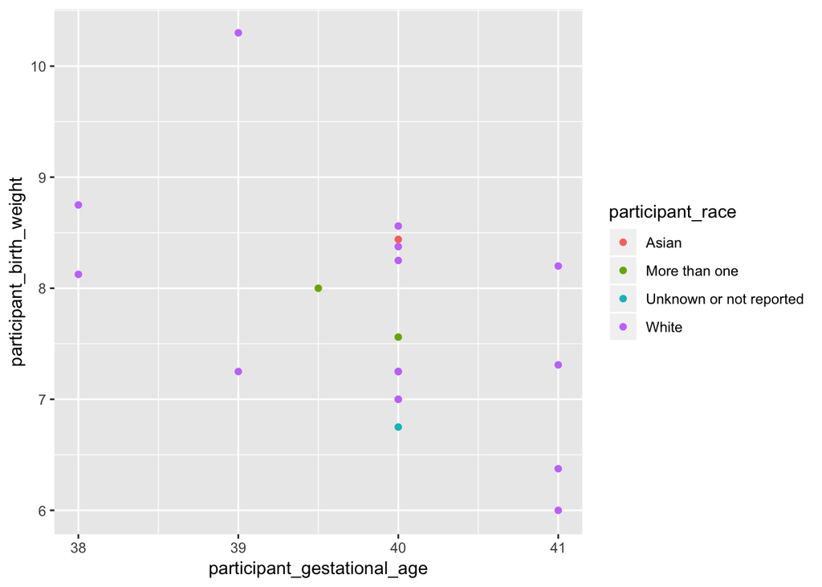

```r
play_demog %>%
  ggplot(.) +
  aes(x = participant_gestational_age, y = participant_birth_weight, color = participant_race) +
  geom_point()
```

## 4.2 Parent surveys

These are some illustrative plots.

### 4.2.1 Sleep hygiene

We have to convert the `sleep.time` and `wake.time` variables so that they can be plotted. It looks like the `lubridate` package is a good option.

```r
# sleep <- lubridate::ymd_hms("2001-01-01 20:30:00")
# awake <- lubridate::ymd_hms("2001-01-02 07:00:00")
# (night_hrs <- awake-sleep)

# Helper functions for conversion
sleep_time <- function(hhmmss){
  lubridate::ymd_hms(paste0("2001-01-01 ", hhmmss))
}
wake_time <- function(hhmmss){
  # One date later than sleep time
  lubridate::ymd_hms(paste0("2001-01-02 ", hhmmss))
}

time_asleep <- function(sleep_tm, awake_tm){
  wake_time(awake_tm) - sleep_time(sleep_tm)
}

sleep_df <- sleep_df %>%
  mutate(sleep_tm = sleep_time(sleep.time),
         wake_tm = wake_time(wake.time),
         nightsleep_hrs = wake_tm - sleep_tm)
```

Now, we can plot.

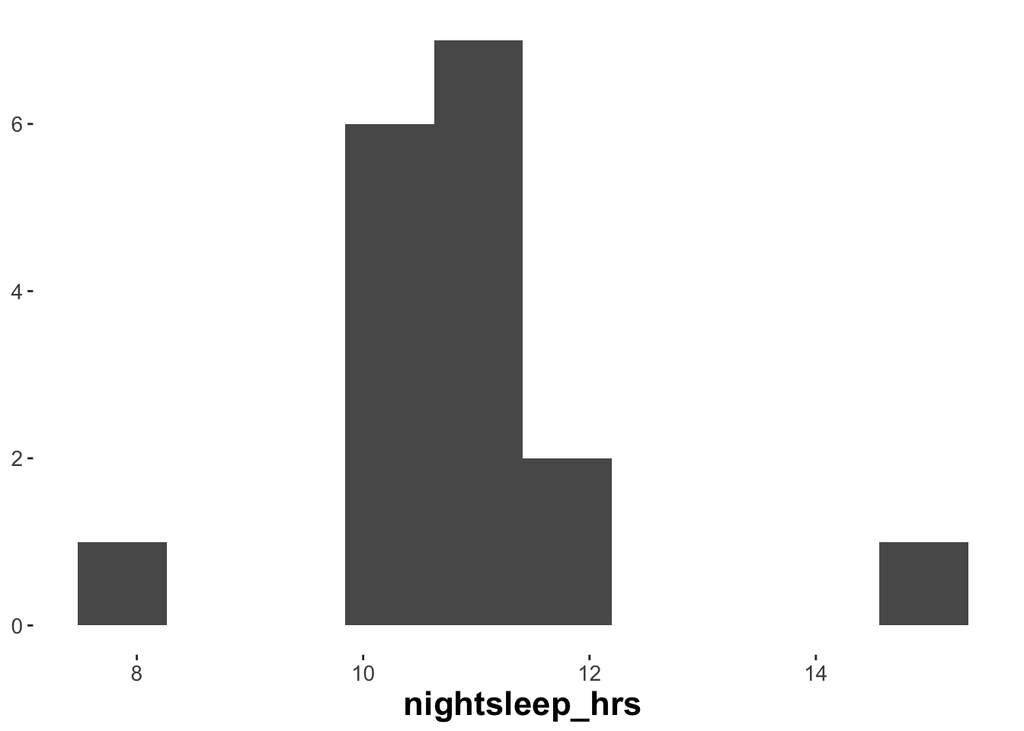

```r
sleep_df %>%
  ggplot(.) +
  aes(x = nightsleep_hrs) +
  geom_histogram(bins = 10) +
  play.theme
```

### 4.2.2 Childcare

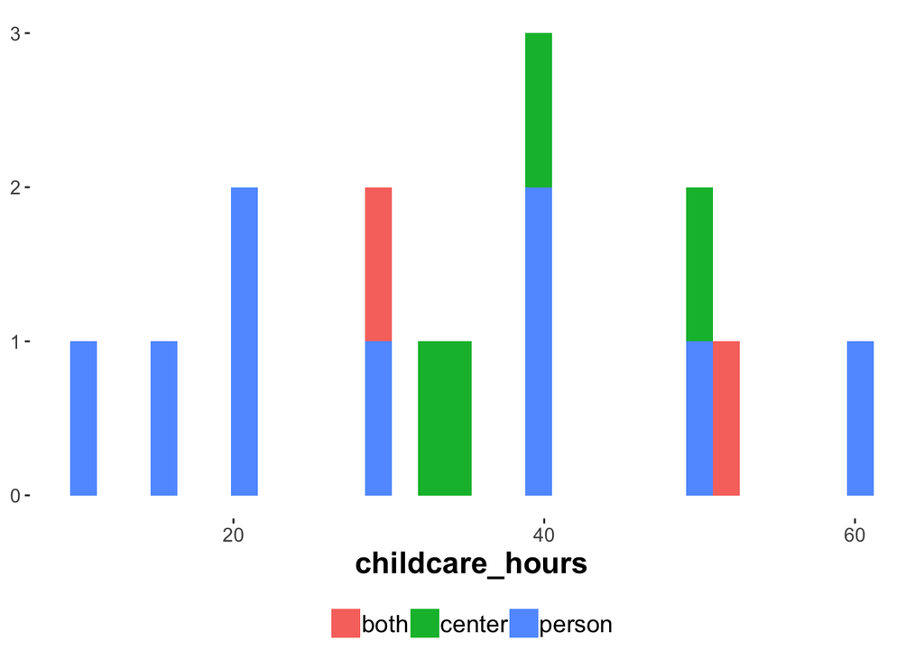

```r
childcare_df %>%
  ggplot(.) +
  aes(x = childcare_hours, fill = childcare_alt) +
  geom_histogram(bins = 30) +
  play.theme
```

### 4.2.3 Language exposure

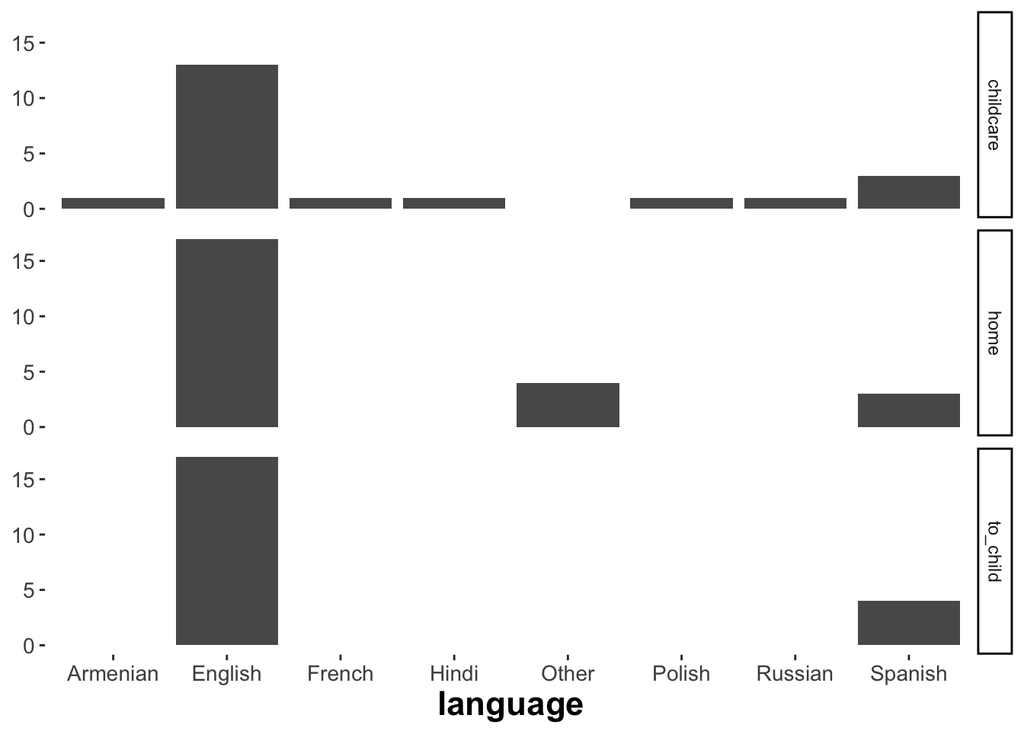

```r
lang_exp_df %>%
  ggplot(.) +
  aes(x = language) +
  facet_grid(exposure_context ~ .) +
  geom_histogram(stat='count') +
  play.theme
```

### 4.2.4 Locomotion onset

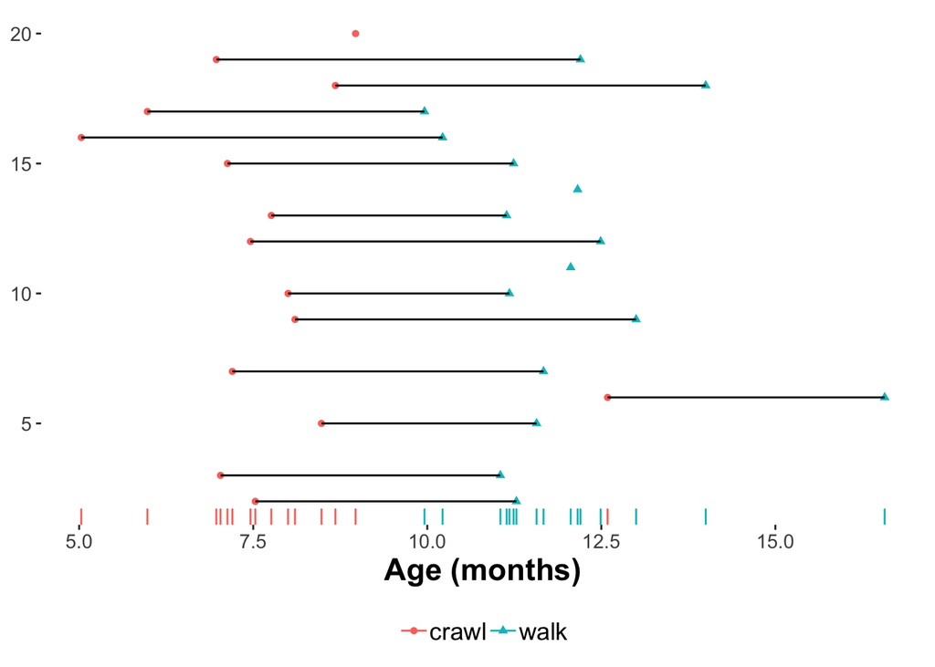

```r
loco_df %>%
  gather(key = milestone, value = age.mos,
         hkcrawl_onset_mos, walk_onset_mos) %>%
  mutate(milestone = factor(milestone,
                            labels = c("crawl", "walk"))) %>%
  ggplot() +
  aes(x = age.mos, y = id) +
  geom_point(aes(shape = milestone, color = milestone)) +
  geom_line(aes(group = id)) +
  xlab("Age (months)") +
  ylab("Participant ID") +
  geom_rug(aes(x = age.mos, group = milestone, color = milestone),
           sides = "b") +
  play.theme
```